# Analyse des données des joueurs (expérimentations finales)

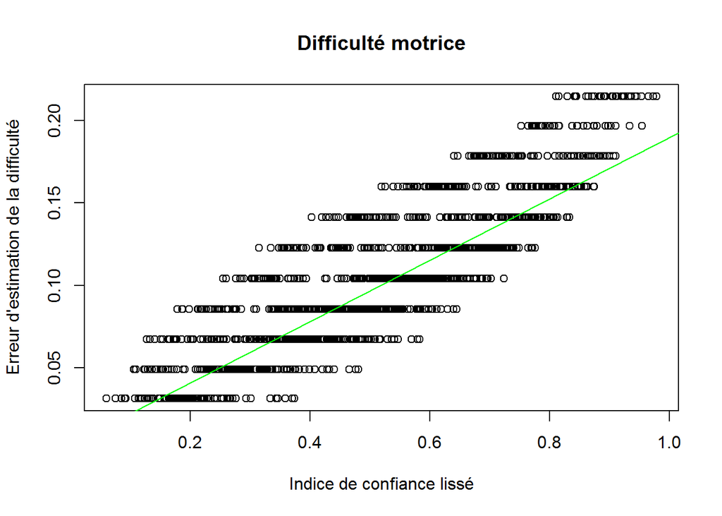

```
## [1] "Anova res lisse"
##               Df Sum Sq Mean Sq F value Pr(>F)
## resLisse       1  2.445  2.4445    4611 <2e-16 ***
## Residuals   2038  1.081  0.0005
## ---
## Signif. codes:  0 '***' 0.001 '**' 0.01 '*' 0.05 '.' 0.1 ' ' 1
## [1] "Regression linéaire"
##
## Call:
## glm(formula = DTLoc$erreurDiffConfiance ~ DTLoc$resLisse)
##
## Deviance Residuals:
##       Min         1Q     Median         3Q        Max
## -0.044780  -0.016526  -0.005259   0.011849   0.062714
##
## Coefficients:
##                Estimate Std. Error t value Pr(>|t|)
## (Intercept)    0.004004   0.001496   2.677  0.00749 **
## DTLoc$resLisse 0.185433   0.002731  67.903  < 2e-16 ***
## ---
## Signif. codes:  0 '***' 0.001 '**' 0.01 '*' 0.05 '.' 0.1 ' ' 1
##
## (Dispersion parameter for gaussian family taken to be 0.0005301636)
##
##     Null deviance: 3.5250  on 2039  degrees of freedom
## Residual deviance: 1.0805  on 2038  degrees of freedom
## AIC: -9593.1
##
## Number of Fisher Scoring iterations: 2
```

```
## [1] "pvalue anova"
```

```
## [1] "0 ***"
```

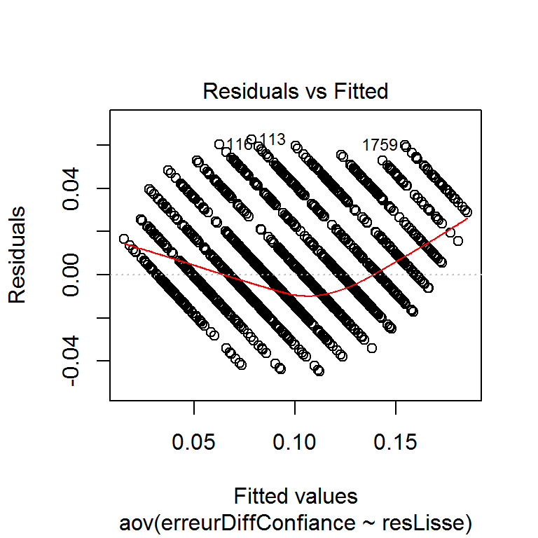

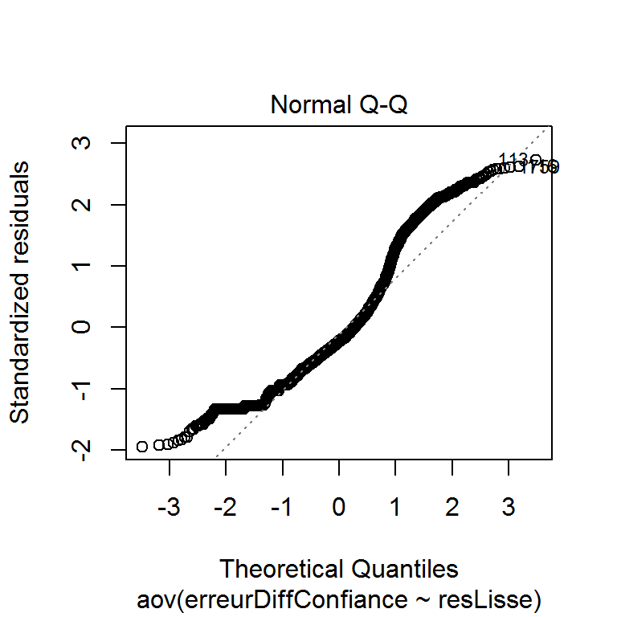

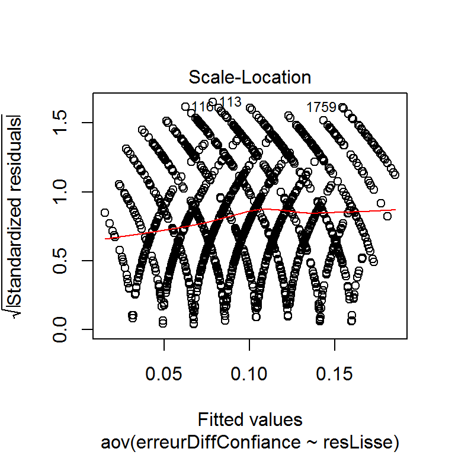

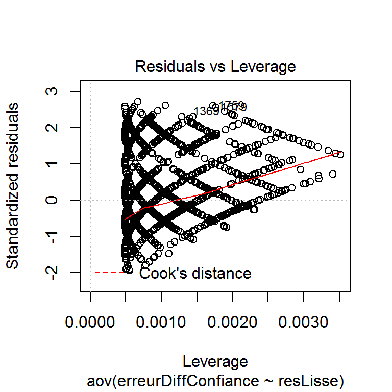

### Courbes de difficulte

```
## [1] "plotDiffCurves == FALSE"
```

## Difficulté sensorielle

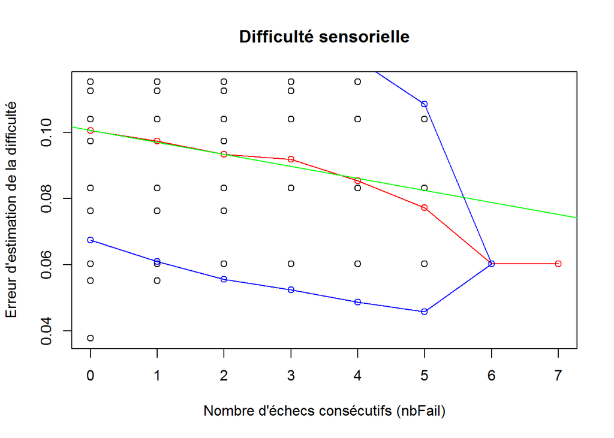

```
## [1] "Anova"
##               Df Sum Sq  Mean Sq F value Pr(>F)
## nbFail         1 0.0254 0.025378   84.06 <2e-16 ***
## Residuals   2098 0.6334 0.000302
## ---
## Signif. codes:  0 '***' 0.001 '**' 0.01 '*' 0.05 '.' 0.1 ' ' 1
## [1] "Regression linéaire"
##
## Call:
## glm(formula = DTLoc$erreurDiffConfiance ~ DTLoc$nbFail)
##
## Deviance Residuals:
##       Min         1Q     Median         3Q        Max
## -0.062912  -0.013827   0.003282   0.014578   0.029135
##
## Coefficients:
##                Estimate Std. Error t value Pr(>|t|)
## (Intercept)   0.1006606  0.0004638 217.036   <2e-16 ***
## DTLoc$nbFail -0.0036392  0.0003969  -9.168   <2e-16 ***
## ---
## Signif. codes:  0 '***' 0.001 '**' 0.01 '*' 0.05 '.' 0.1 ' ' 1
##
## (Dispersion parameter for gaussian family taken to be 0.0003019257)
##
##     Null deviance: 0.65882  on 2099  degrees of freedom
## Residual deviance: 0.63344  on 2098  degrees of freedom
## AIC: -11058
##
## Number of Fisher Scoring iterations: 2
```

```
## [1] "pvalue anova"
```

```
## [1] "1.1e-19 ***"
```

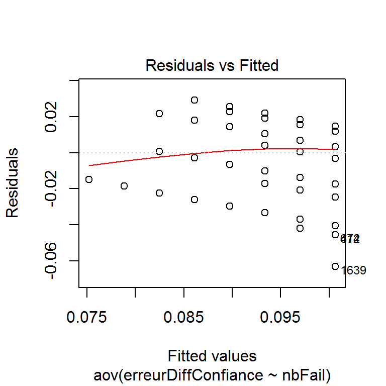

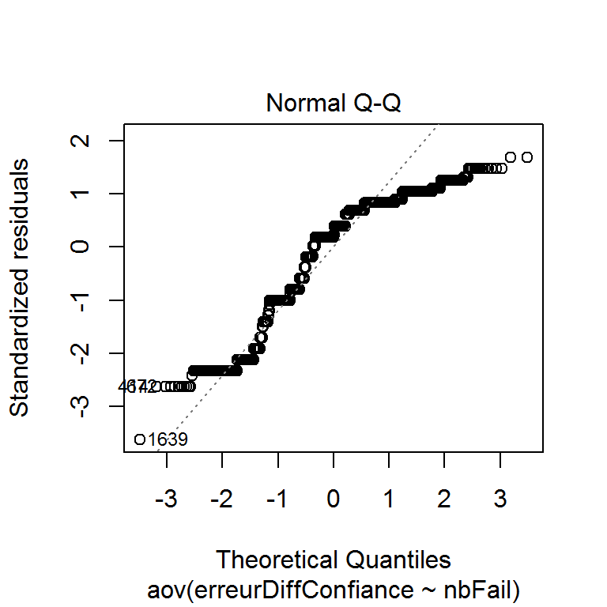

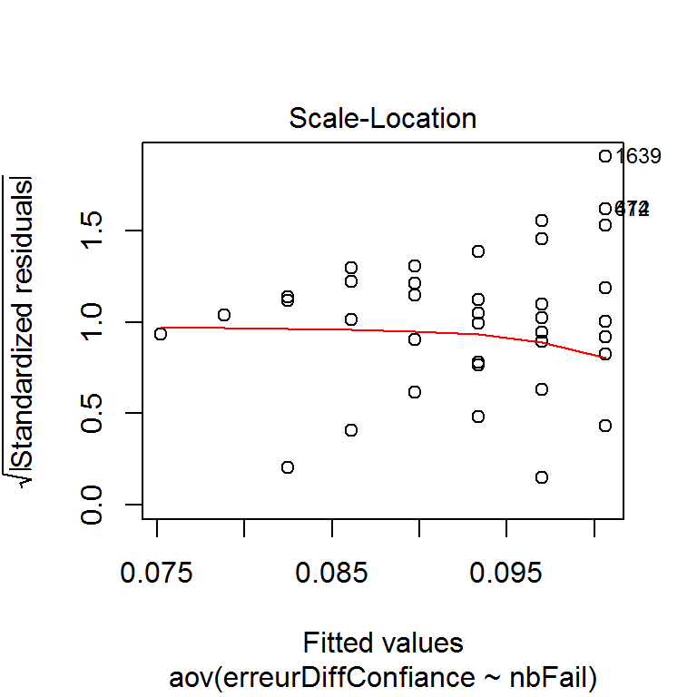

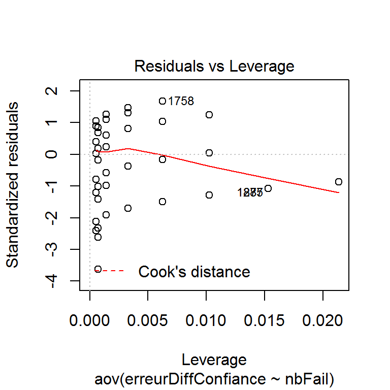

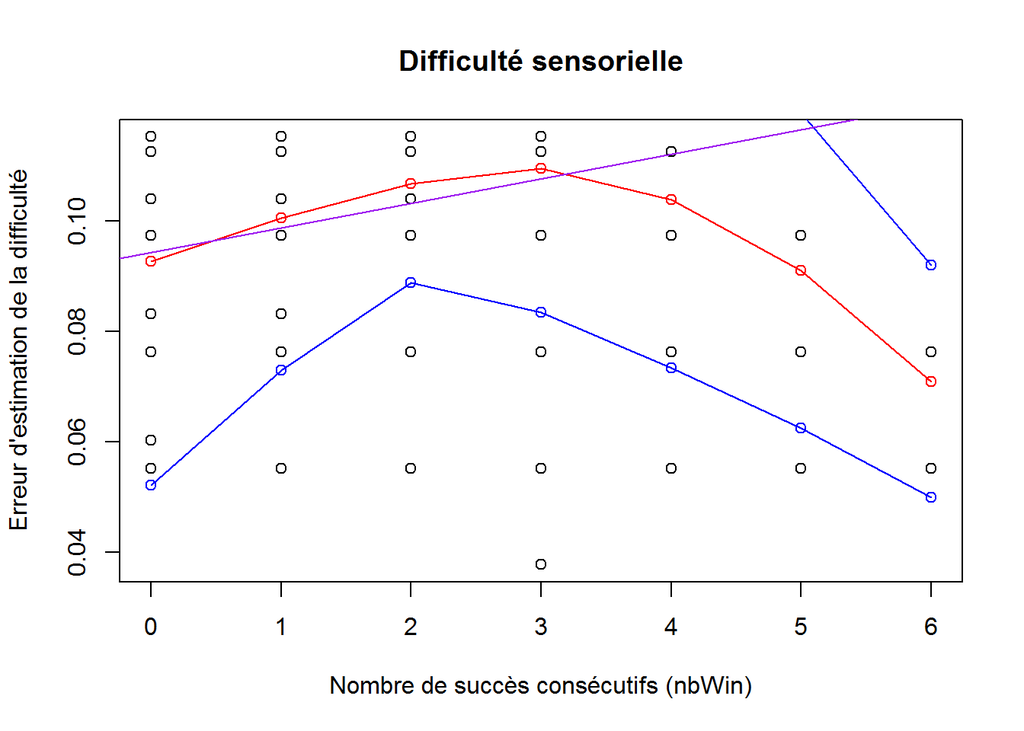

```
## [1] "Anova"
##               Df Sum Sq Mean Sq F value Pr(>F)
## nbWin          1 0.0485 0.04853   166.8 <2e-16 ***
## Residuals   2098 0.6103 0.00029
## ---
## Signif. codes:  0 '***' 0.001 '**' 0.01 '*' 0.05 '.' 0.1 ' ' 1
## [1] "Regression linéaire"
##
## Call:
## glm(formula = DTLoc$erreurDiffConfiance ~ DTLoc$nbWin)
##
## Deviance Residuals:
##       Min         1Q     Median         3Q        Max
## -0.069850  -0.011070   0.005233   0.012085   0.020974
##
## Coefficients:
##              Estimate Std. Error t value Pr(>|t|)
## (Intercept) 0.0942648  0.0004816  195.75   <2e-16 ***
## DTLoc$nbWin 0.0044446  0.0003441   12.92   <2e-16 ***
## ---
## Signif. codes:  0 '***' 0.001 '**' 0.01 '*' 0.05 '.' 0.1 ' ' 1
##
## (Dispersion parameter for gaussian family taken to be 0.0002908903)
##
##     Null deviance: 0.65882  on 2099  degrees of freedom
## Residual deviance: 0.61029  on 2098  degrees of freedom
## AIC: -11136
##
## Number of Fisher Scoring iterations: 2
```

```
## [1] "pvalue anova"
```

```
## [1] "8.8e-37 ***"
```

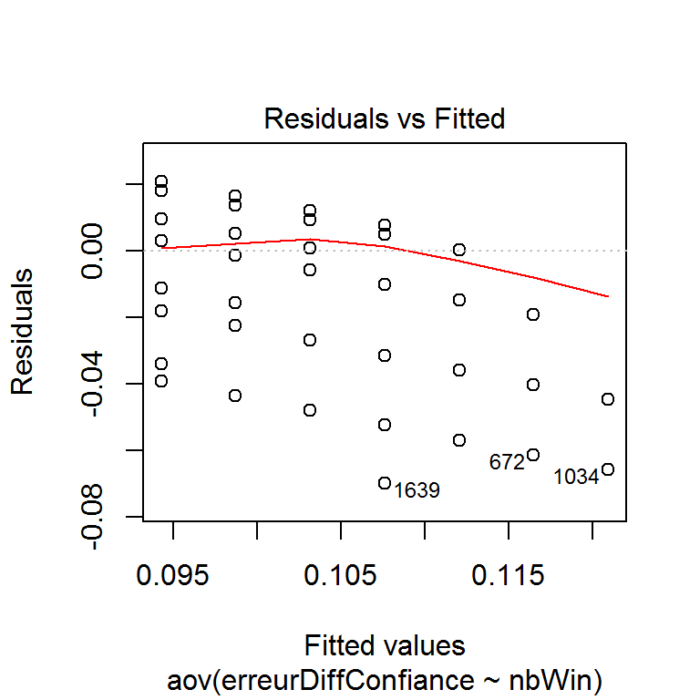

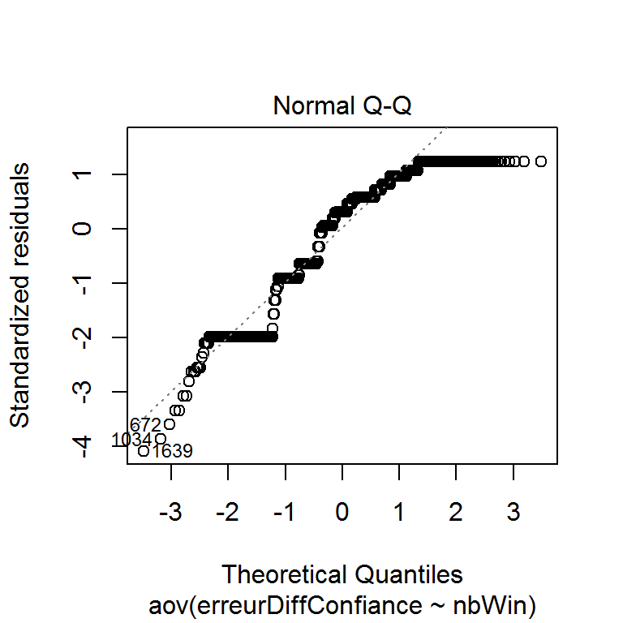

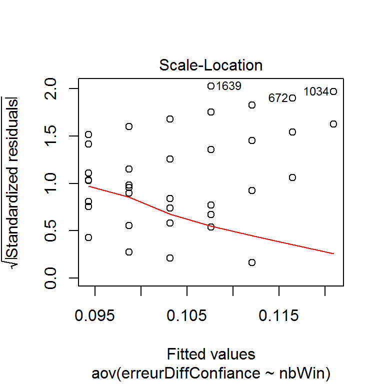

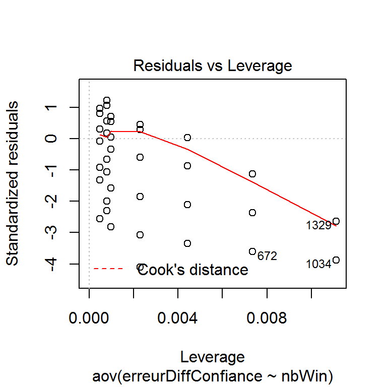

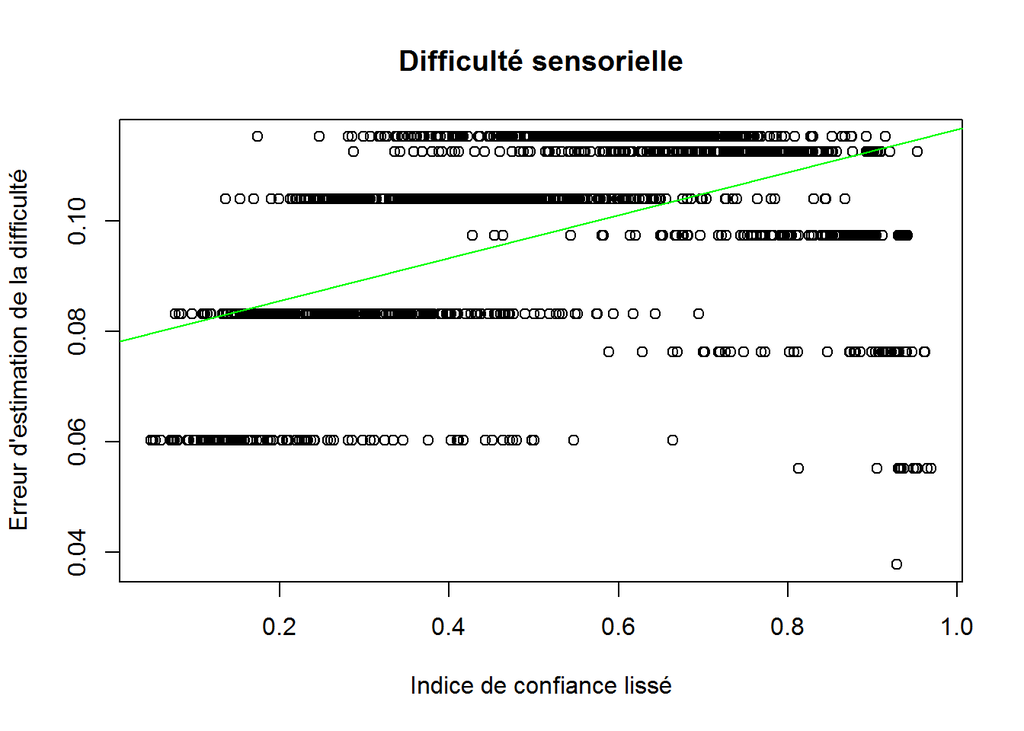

```
## [1] "Anova res lisse"
##               Df Sum Sq Mean Sq F value Pr(>F)
## resLisse       1 0.1305 0.13046     518 <2e-16 ***
## Residuals   2098 0.5284 0.00025
## ---
## Signif. codes:  0 '***' 0.001 '**' 0.01 '*' 0.05 '.' 0.1 ' ' 1
## [1] "Regression linéaire"
##
## Call:
## glm(formula = DTLoc$erreurDiffConfiance ~ DTLoc$resLisse)
##
## Deviance Residuals:
##       Min         1Q     Median         3Q        Max
## -0.076082  -0.009223   0.004793   0.011333   0.030665
##
## Coefficients:
##                 Estimate Std. Error t value Pr(>|t|)
## (Intercept)    0.0778321  0.0009601   81.07   <2e-16 ***
## DTLoc$resLisse 0.0387527  0.0017027   22.76   <2e-16 ***
## ---
## Signif. codes:  0 '***' 0.001 '**' 0.01 '*' 0.05 '.' 0.1 ' ' 1
##
## (Dispersion parameter for gaussian family taken to be 0.0002518409)
##
##     Null deviance: 0.65882  on 2099  degrees of freedom
## Residual deviance: 0.52836  on 2098  degrees of freedom
## AIC: -11439
##
## Number of Fisher Scoring iterations: 2
```

```
## [1] "pvalue anova"
```

```
## [1] "1.2e-102 ***"
```

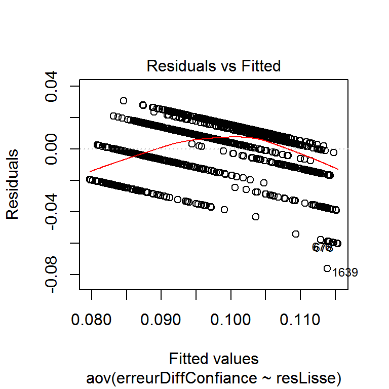

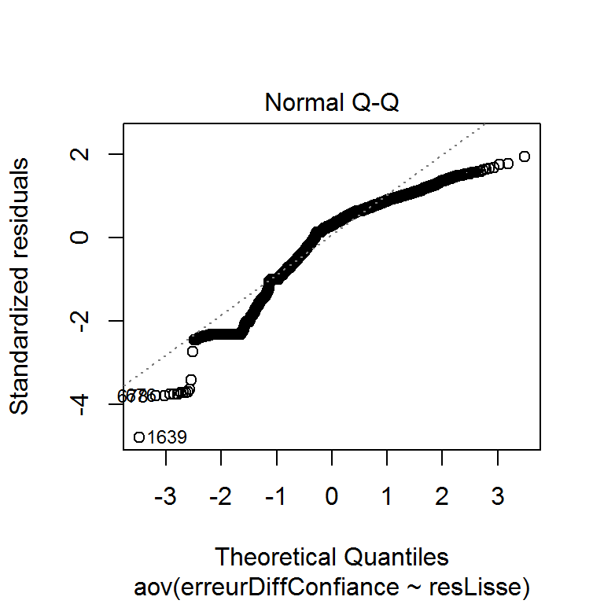

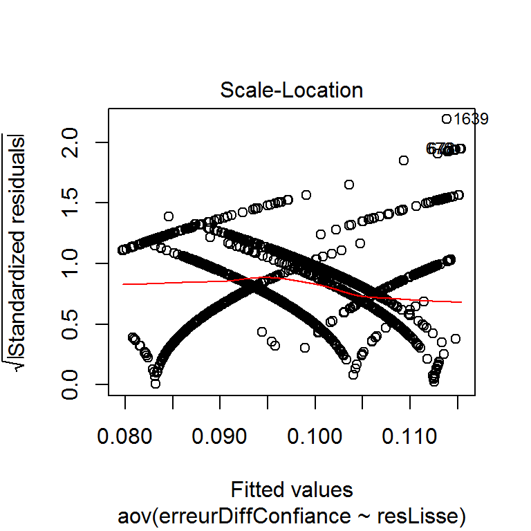

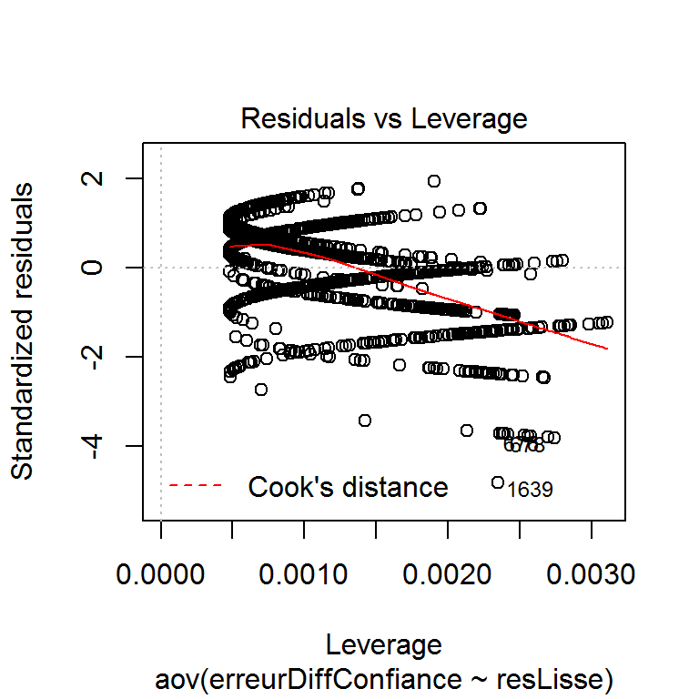

### Courbes de difficulte

```
## [1] "plotDiffCurves == FALSE"
```

# Summary des pvalues

- All lissee 0 ***
- Motrice lissee 0 ***
- Senso lissee 1.2e-102 ***
- Logique lissee 0 ***
- All NBWin 3.1e-57 ***
- Motrice NBWin 6.3e-86 ***
- Senso NBWin 8.8e-37 ***
- Logique NBWin 4.5e-68 ***
- All NBFails 5.1e-16 ***
- Motrice NBFails 1.6e-32 ***
- Senso NBFails 1.1e-19 ***
- Logique NBFails 1.9e-10 ***

# Analyses complémentaires

On teste ici une faiblesse éventuelle du modèle. Nous considérons qu’un joueur a une perception faussée de la difficultée si la difficulté objective globale $d_{og}$ est différente de la difficulté subjective $d_{s}$. $d_{og}$ est calculée sur l’ensemble du groupe . $d_{s}$ correspond à la mise du joueur normalisée. Nous étudions le rapport entre nombre d’échecs consécutifs $n_{fail}$ ou nombre de réussites consécutifs $n_{win}$ et l’erreur d’estimation $\epsilon = d_{s} - d_{og}$.

$d_{og}$ a une faiblesse: elle est calculée sur l’ensemble du groupe et donc ne tient pas compte du niveau spécifique de chaque joueur, elle s’éloigne donc de la difficulté réelle $d_{r}$ pour les joueurs qui sortent de la moyenne du groupe, bons ou mauvais. Donc plus un joueur s’éloigne de la moyenne des joueurs, plus l’erreur d’évaluation de la difficulté va être importante: même si $d_{s}$ est parfaite, $\mid d_{s}-d_{og} \mid$ va augmenter car $d_{og}$ devient de plus en plus fausse. Autrement dit, la correlation entre $n_{win}$ et $\epsilon$ provient elle d’une erreur sur la difficulté subjective (exces de confiance) ou sur la difficulté objective. Car justement, plus un joueur est bon (ou mauvais) plus il a de chance d’avoir des suites de succès (ou d’échecs), avant que la difficulté se soit adaptée, ce qui pourrait expliquer une corrélation entre $d_{og}$ et $n_{win}$.

# Idees

- enregistrer les timecodes a chaque ligne, pouir filtrer ceux qui jouent très vite ou très lentement, ou regarder les temps de réponse
- mettre difficulté totalement aléatoire (supprimer le lien entre d(n-1) et d(n))
- avoir une mise plus précise que 0/1